# Supervised Learning - Classification 01

# Metric Evaluasi yang lain

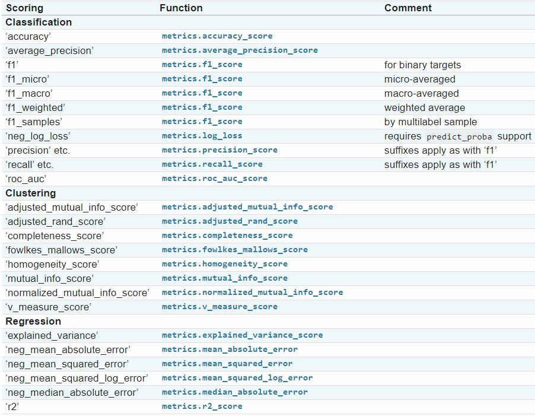

## http://scikit-learn.org/stable/modules/model_evaluation.html

## Confusion Matrix

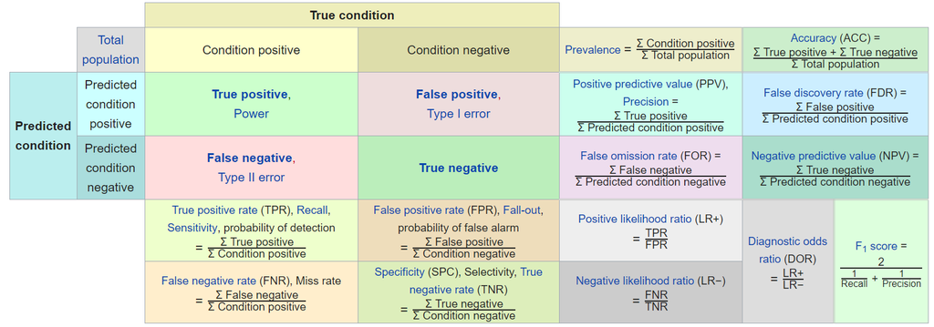

- sensitivity, recall, hit rate, or true positive rate (TPR)
- precision or positive predictive value (PPV)

[figure not shown]

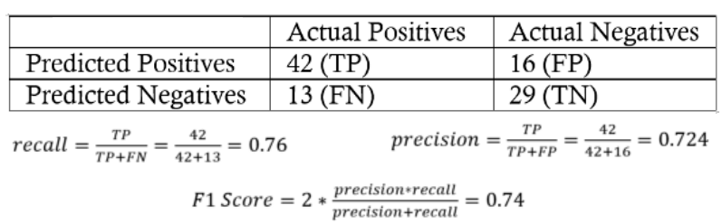

* Yang mana kategori yang "positif"?

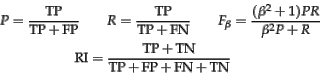

- $0\leq F\leq 1$, 1 optimal value
- $0\leq\beta< \inf$
- beta < 1 lends more weight to precision,
- beta > 1 favors recall
- beta -> 0 considers only precision
- beta -> inf only recall

# Aplikasi di Python untuk metrics diatas:

```python
from sklearn.metrics import precision_score, recall_score, f1_score

print('presisi = ', precision_score(y_test, y_reglog))
print('Recall = ', recall_score(y_test, y_reglog))
print('f1_score = ', f1_score(y_test, y_reglog))
```

```
presisi =  0.9771428571428571
Recall =  0.9193548387096774
f1_score =  0.9473684210526316
```

# Atau ...

```python
from sklearn.metrics import confusion_matrix, classification_report

print(confusion_matrix(y_test, y_reglog))
print(classification_report(y_test, y_reglog))
```

```
[[ 95   4]
 [ 15 171]]
              precision    recall  f1-score   support

           0       0.86      0.96      0.91        99
           1       0.98      0.92      0.95       186

    accuracy                           0.93       285
   macro avg       0.92      0.94      0.93       285
weighted avg       0.94      0.93      0.93       285
```

# Evaluasi yang kita lakukan belum cukup valid/objektif ... Mengapa?

# Cross Validation

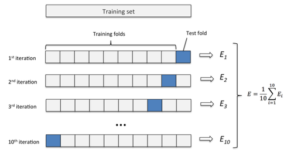

```python
# Cross validation
# Perhatikan variabelnya, kita sekarang menggunakan seluruh data
# http://scikit-learn.org/stable/modules/generated/sklearn.model_selection.cross_val_score.html
from sklearn.model_selection import cross_val_score
import time

mulai = time.time()
scores_regLog = cross_val_score(clf, X, Y, cv=10) # perhatikan sekarang kita menggunakan seluruh data
waktu = time.time() - mulai
# Interval Akurasi 95 CI
print("Accuracy Regresi Logistik: %0.2f (+/- %0.2f), Waktu = %0.3f detik" % (scores_regLog.mean(), scores_regLog.std() * 2, waktu))
```

```
Accuracy Regresi Logistik: 0.94 (+/- 0.03), Waktu = 0.134 detik
```

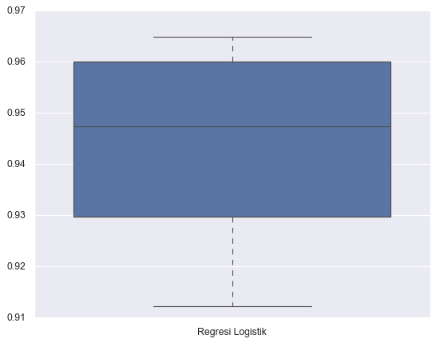

```python
# Kita juga bisa menampilkan BoxPlotnya untuk mendapatkan informasi yang lebih lengkap
%matplotlib inline
import matplotlib.pyplot as plt; plt.style.use('classic')
import seaborn as sns; sns.set()

df = pd.DataFrame({'Regresi Logistik':scores_regLog})
sns.boxplot(data=df)
plt.show()
```

# Regresi Logistik untuk Multiclass Classification?

## Salah satu caranya: One Versus All (OVA) Approach

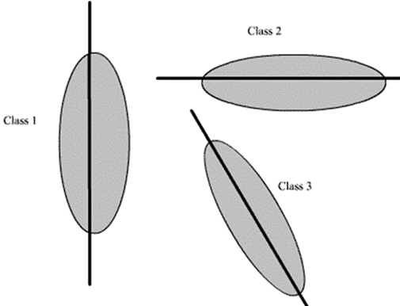

## Aplikasi di Python?

```python
from sklearn.datasets import load_iris
X, y = load_iris(return_X_y=True)
set(y) # 3 Kategori
```

```
{0, 1, 2}
```

```python
X.shape # 4 variabel, 150 baris
```

```
(150, 4)
```

```python
clf = LogisticRegression(multi_class='ovr').fit(X, y)
clf.coef_
# Perhatikan ada 3 persamaan
```

```
array([[-0.44501376,  0.89999242, -2.32353827, -0.97345836],
       [-0.1792787 , -2.12866718,  0.69665417, -1.27480129],
       [-0.39444787, -0.5133412 ,  2.93087523,  2.41709879]])
```

# k-Nearest Neighbour

[figure not shown]

### k-Nearest Neighbour

- Classifier yang paling sederhana, namun dapat juga digunakan untuk regresi (dan bahkan clustering).
- Sering disebut sebagai **Instance based Learner**
- Tidak memiliki "persamaan", pendekatannya lebih ke algoritmik berdasarkan konsep jarak/similarity
- Mirip konsep DBSCAN

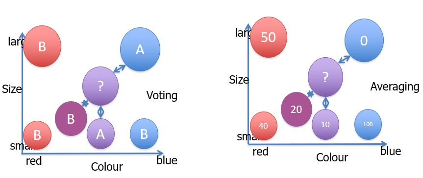

## k-NN Neighbour Size

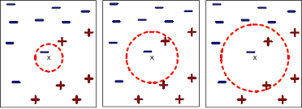

**Pros:**

- Relatif cepat (efisien) untuk data yang tidak terlalu besar
- Sederhana, mudah untuk diimplementasikan
- Mudah untuk di modifikasi: Berbagai macam formula jarak/similaritas
- Menangani data Multiclass dengan mudah
- Akurasi cukup baik jika data representatif

**Cons:**

- Menemukan nearest neighbours tidak efisien untuk data besar
- Storage of data
- Meyakinkan rumus jarak yang tepat

## Similarity (Distance)

- Euclidean (“straight line”, distance between two points)
- Manhattan (sum of absolute differences of all attributes)
- Maximal (greatest of absolute differences between attributes)  
  d(x,y) = max{|x_i-y_i|, i =1,2,...,n}
- Mahalanobis (distance between point and distribution).

## Euclidean Distance

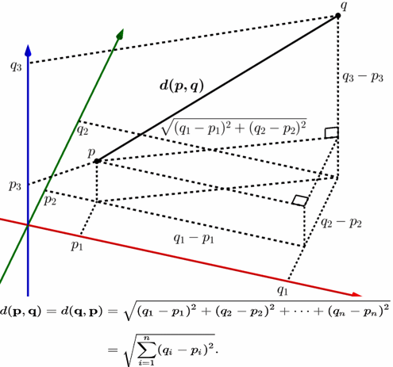

## Manhattan Distance

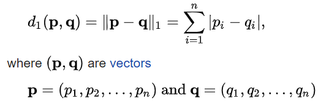

## Similarity explained in plain terms and its application in Python

### http://dataaspirant.com/2015/04/11/five-most-popular-similarity-measures-implementation-in-python/

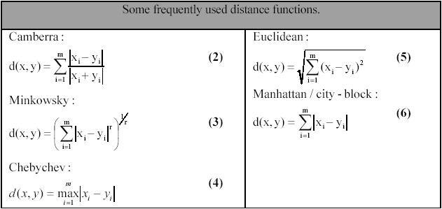

## The Weights in k-NN:

- **Uniform**: all points in each neighborhood are weighted equally.
- **Distance**: closer neighbors of a query point have a greater influence than the neighbors further away.

# Aplikasi di Python

```python
# k-NN: http://scikit-learn.org/stable/modules/neighbors.html
from sklearn import neighbors

n_neighbors = 3
weights = 'distance'
kNN = neighbors.KNeighborsClassifier(n_neighbors, weights=weights)
kNN.fit(X_train, y_train)
print('Done!')
```

```
Done!
```

```python
# Prediksi dengan k-NN
y_kNN = kNN.predict(X_test)
y_kNN[-10:]
```

```
array([0, 1, 0, 1, 0, 0, 0, 1, 0, 1])
```

```python
# Akurasi
accuracy_score(y_test, y_kNN)
```

```
0.9263157894736842
```

```python
# Cross Validasi
del kNN
kNN = neighbors.KNeighborsClassifier(n_neighbors, weights=weights)

mulai = time.time()
scores_kNN = cross_val_score(kNN, X, y, cv=10) # perhatikan sekarang kita menggunakan seluruh data
waktu = time.time() - mulai
# Interval Akurasi 95 CI
print("Accuracy kNN: %0.2f (+/- %0.2f), Waktu = %0.3f detik" % (scores_kNN.mean(), scores_kNN.std() * 2, waktu))
```

```
Accuracy kNN: 0.97 (+/- 0.09), Waktu = 0.016 detik
```

# Decision Tree (Pohon Keputusan)

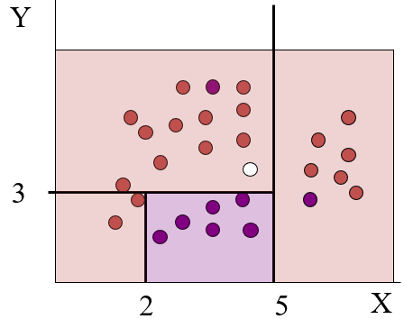

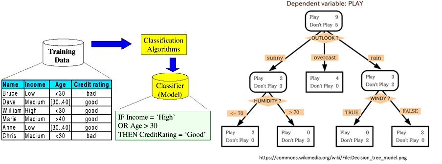

[figure not shown]